# UMAP on some simple datasets

## Random Noise

A single high-dimensional Guassian:

```r
gauss100d <- snedata::gaussian_data(n = 500, dim = 100, color = "#003399")
```

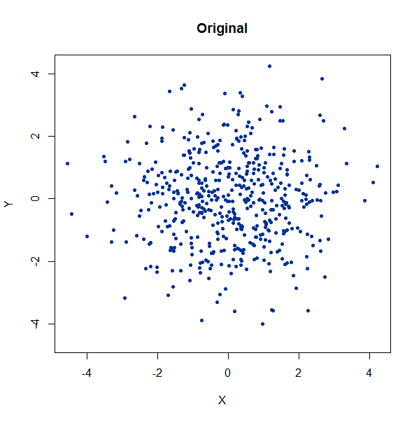

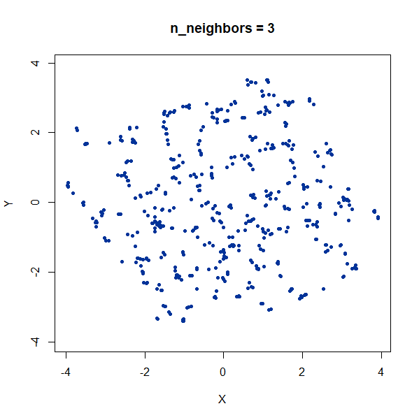

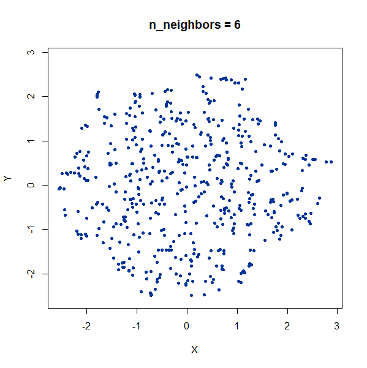

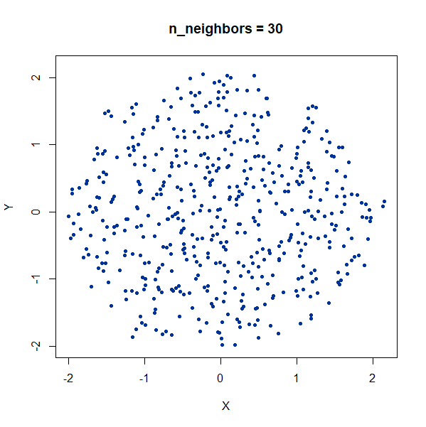

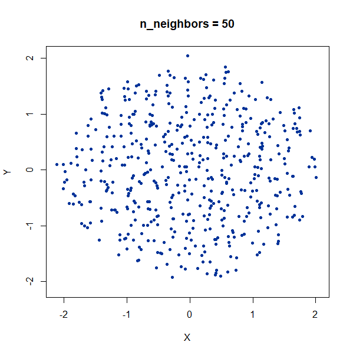

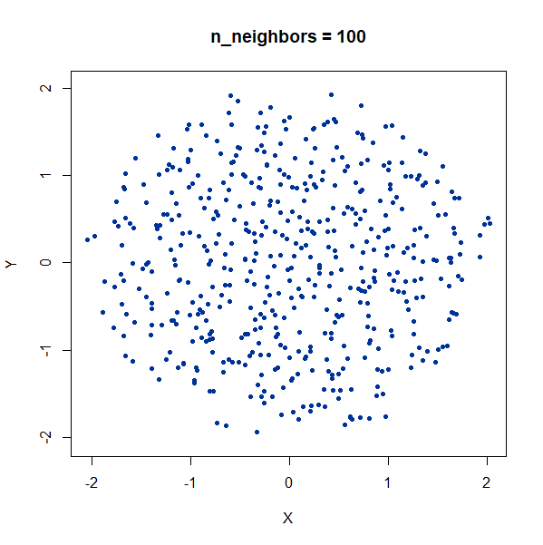

Again, we see t-SNE-like behavior: the density of points in the projection is more even than the linear projection provided by PCA. It’s also clear that low values of `n_neighbors` could mislead you into seeing large numbers of small clusters that aren’t really there.

## Elongated Shapes

An ellipsoidal cluster:

```r
gauss_long <- snedata::long_gaussian_data(n = 100, dim = 50, color = "#003399")
```

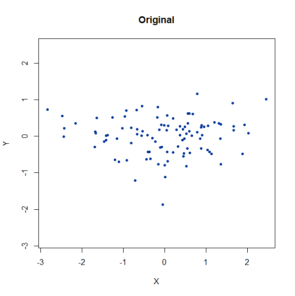

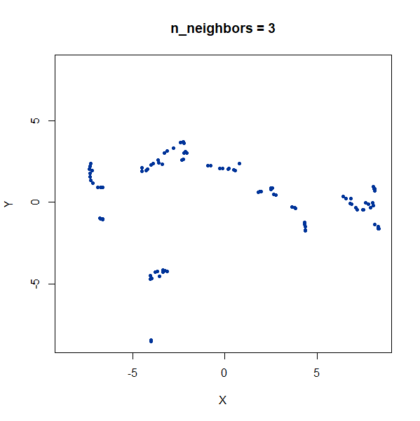

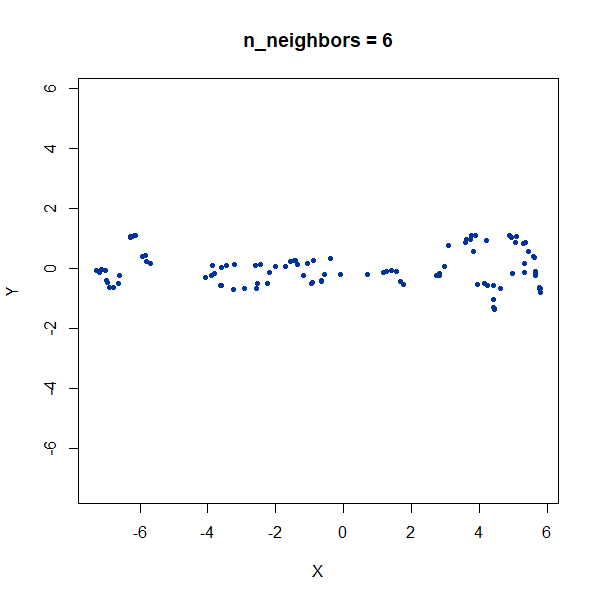

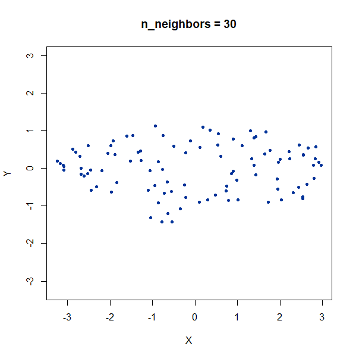

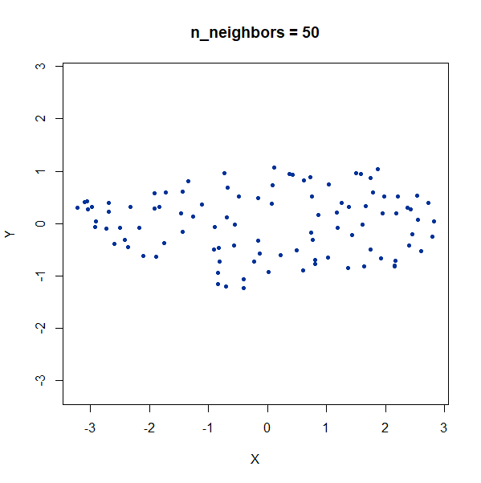

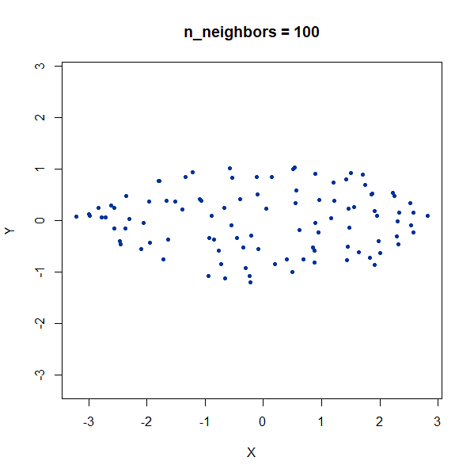

Once again, UMAP behaves pretty well here as long as `n_neighbors` is sufficiently high.

Now, here are two ellipsoidal clusters:

```r
gauss_2long <- snedata::long_cluster_data(n = 75)
```

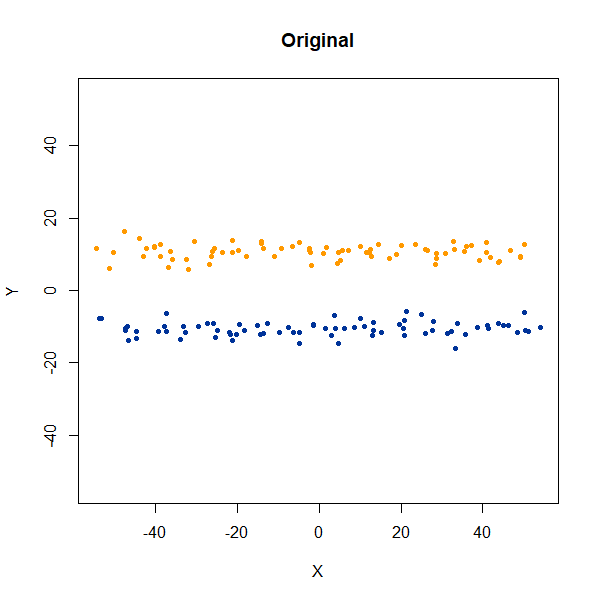

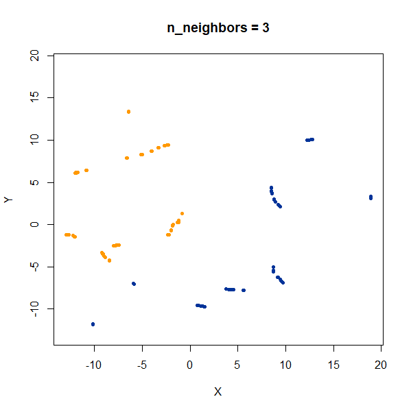

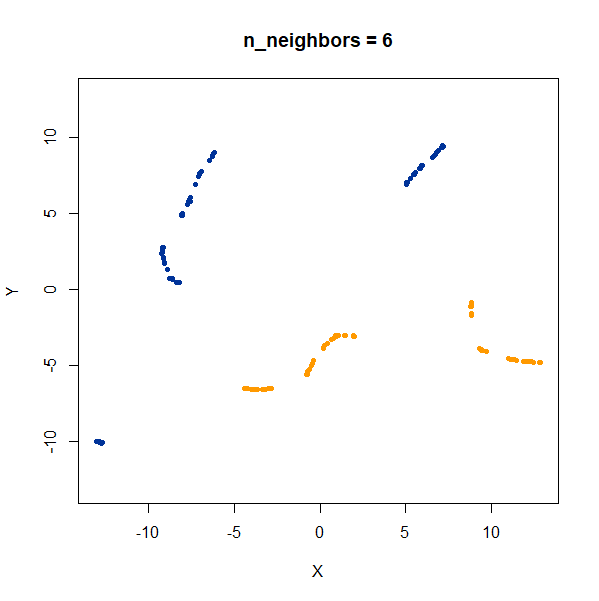

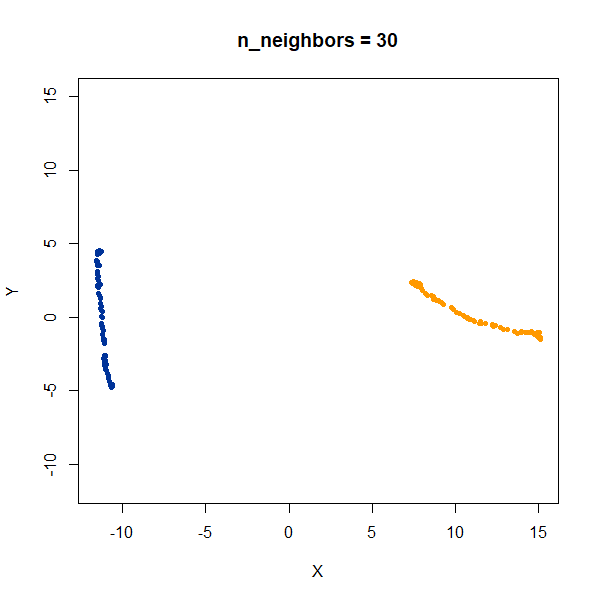

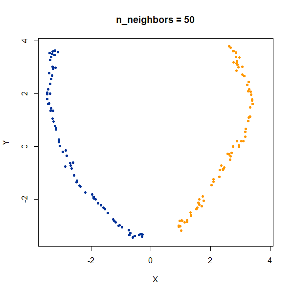

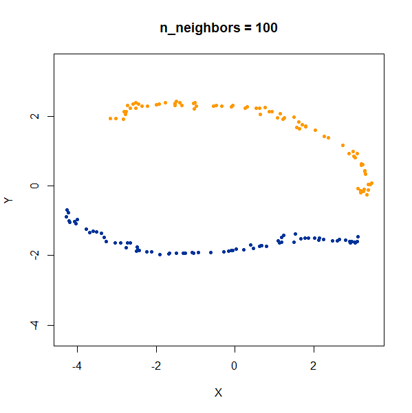

The density distortion effect is also apparent here, causing the clusters to curve.

## Topology

### Containment

In this dataset, there are two 50D gaussian clusters, centered over the same location, but as the PCA plot on the top left row shows, the blue cluster has a much smaller variance and so is “contained” inside the yellow cluster.

```r
subset50d <- snedata::subset_clusters_data(n = 75, dim = 50)
```

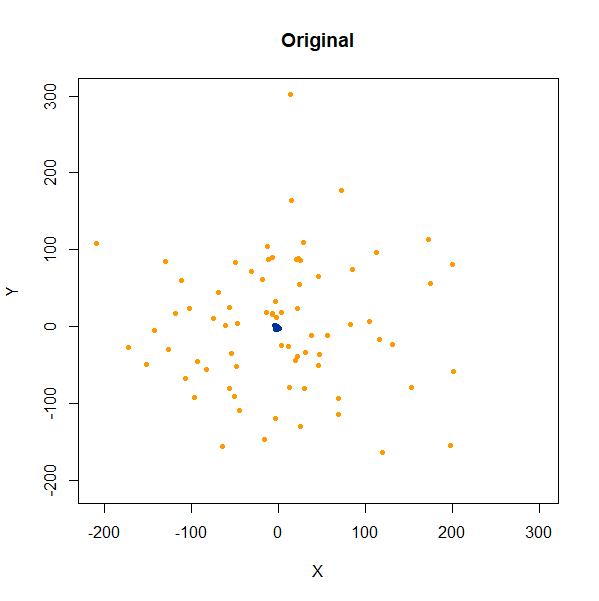

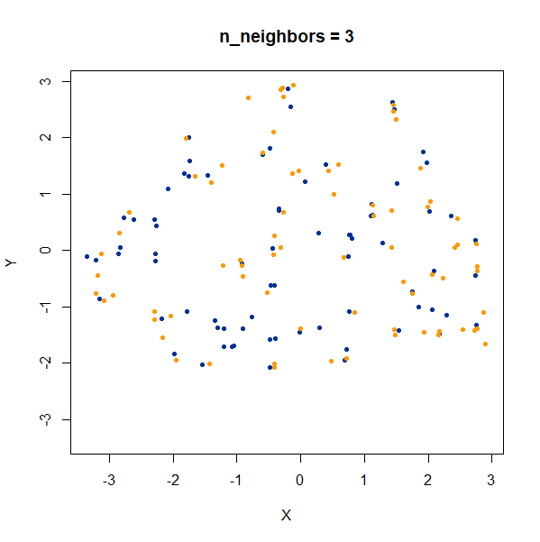

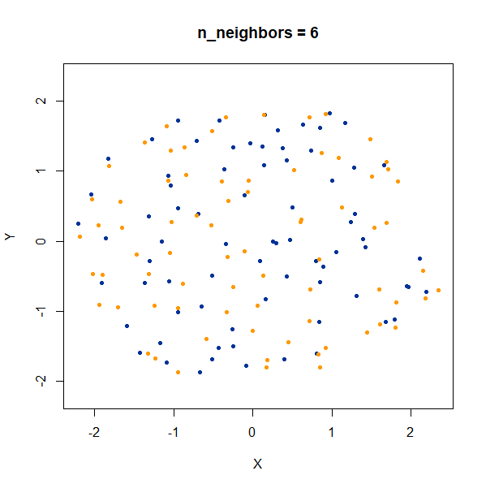

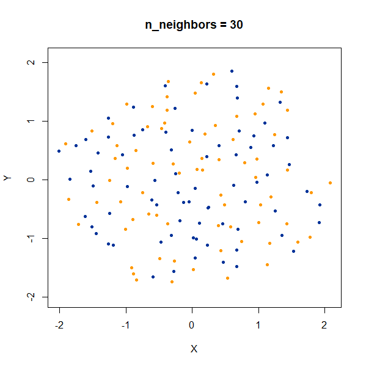

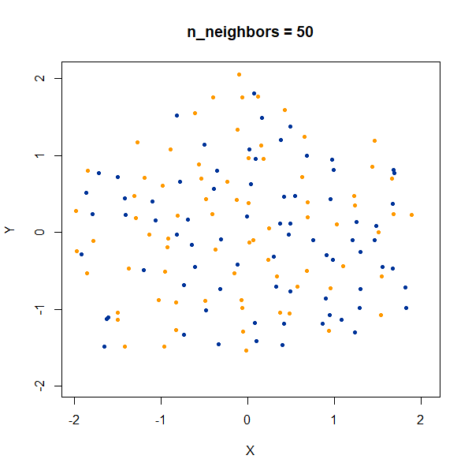

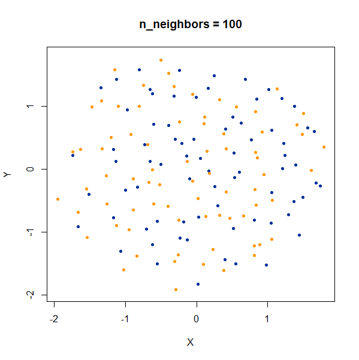

At last a difference with the t-SNE results. With t-SNE, the containment relationship can be displayed with a suitable choice of perplexity, at the cost of the yellow cluster gaining a more ring-like shape. UMAP, however, stubbornly refuses to show anything of the sort, with the blue cluster expanded to overlap the yellow cluster even at the higher values of `n_neighbors`.

### Linked Rings

2D linked rings, embedding into 3D (one is at right angles to the other).

```r
linked_rings <- snedata::link_data(n = 100)
```

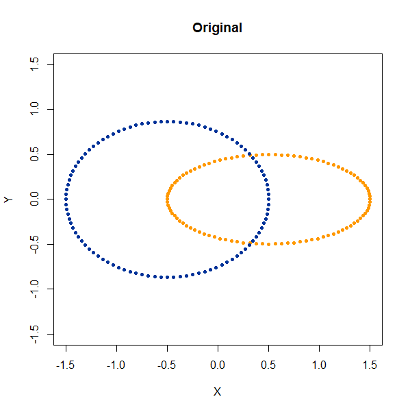

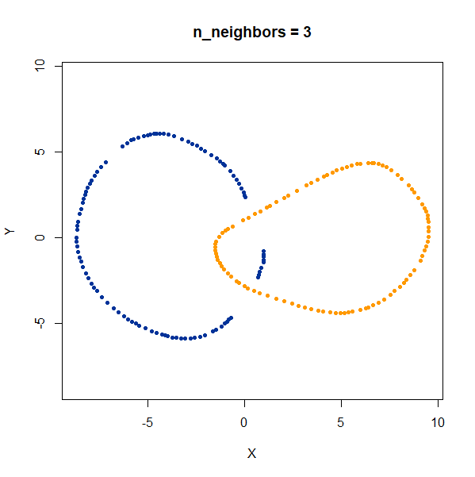

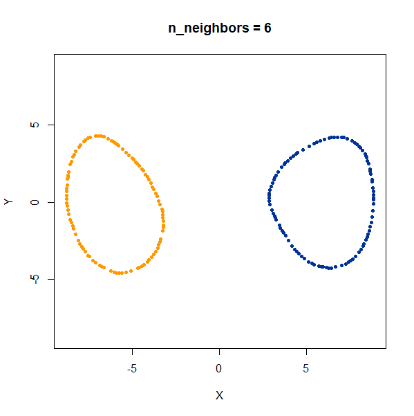

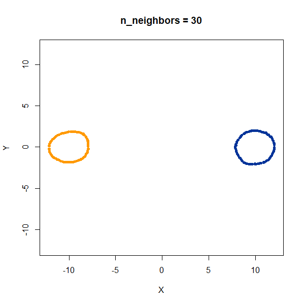

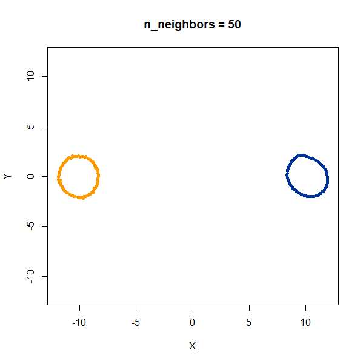

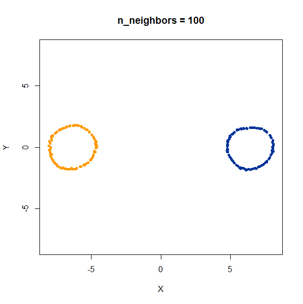

The t-SNE results show the rings between separate at low perplexity, and only linked at high perplexities. The UMAP results are always unlinked except at a very low value of `n_neighbors`, and even then this seems to be an artifact of the number of epochs and the random seed. If you set `n_epochs` higher, then the rings will be invariably unlinked.

### Trefoil Knot

```r
trefoil <- snedata::trefoil_data(n = 150)
```

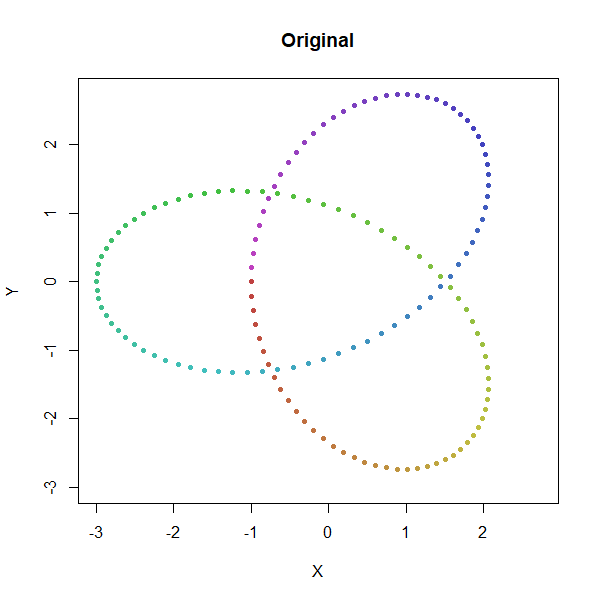

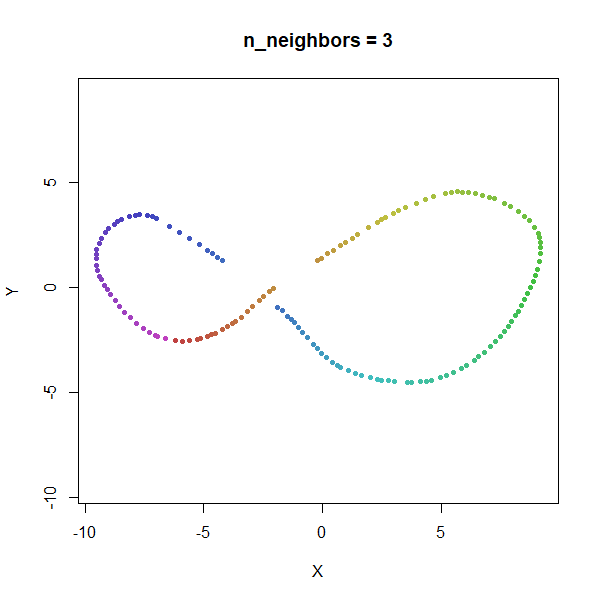

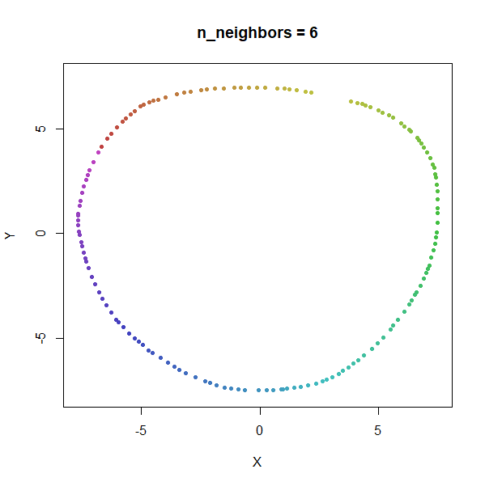

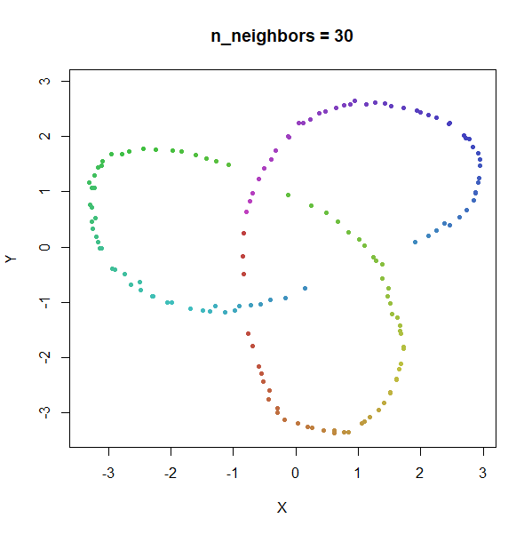

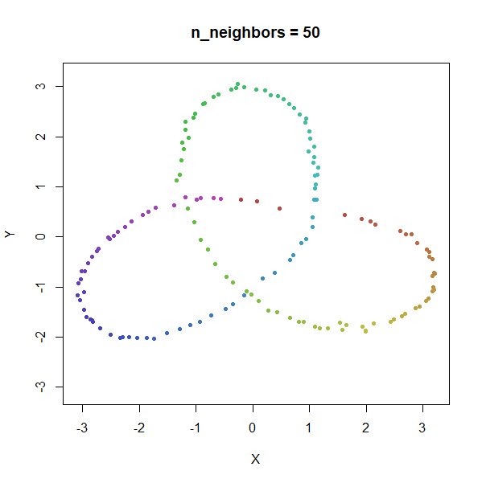

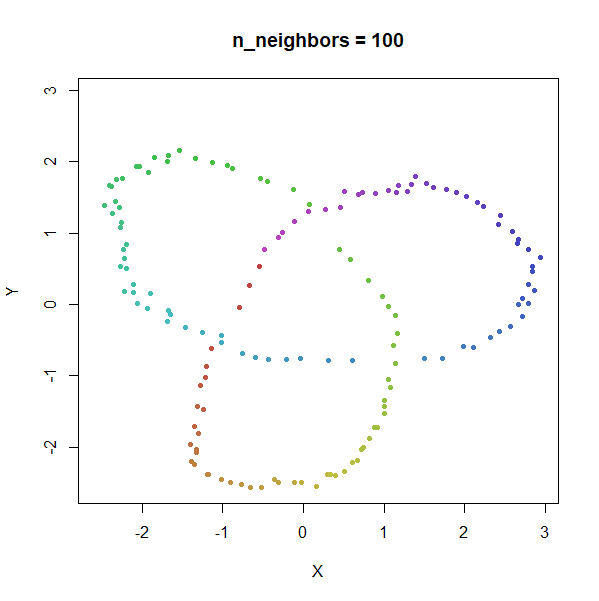

Results here are quite similar to the t-SNE results. At low values of `n_neighbors`, the knot is unfolded into a circle, and at higher values, the folded form appears. As with the linked rings, the results you get at low values of `n_neighbors` are more consistent at higher values of `n_epochs`.

What are we to make of all this? Mainly, that the UMAP results are a bit more consistent than that of t-SNE, in the sense that changing `n_neighbors` doesn’t lead to very different results in the way that changing `perplexity` does for t-SNE, although these effects are mainly restricted to the three cluster and the containment example. You may see this as an advantage to t-SNE. Personally, I am a bit skeptical that you would see this sort of thing in real world datasets.

It’s also worth noting that, like t-SNE:

- Inter-cluster distances are not reproduced.
- Relative cluster sizes are not reproduced.
- Denser regions of space are expanded more than less dense parts.